# Exploratory Data Analysis Example

The New York City (NYC) AirBnB Dataset

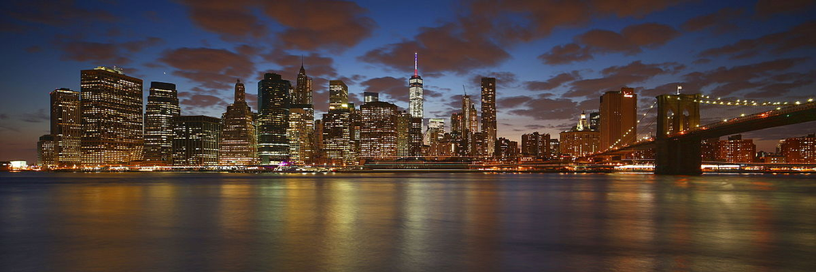

# Task

The ISDL Property Management LC plans to let some of their accommodations in New York City (NYC) via AirBnB. To find out what accommodations can generate the highest rent, they crawled the AirBnB data of NYC.  
As a junior data scientist, you have been asked to apply your new knowledge about exploratory data analysis and hypothesis testing to figure out what accommodations have the highest rent.

## Data Overview

First, we look at the general structure of the dataset and the characteristics of the attributes.

Number of attributes in the dataset: 16  
Number of observations in the dataset: 48895

##### Attributes

```
## # A tibble: 16 x 3
##    AttributeNames          Datatype Description
##    <chr>                   <chr>    <chr>
##  1 id                      numeric  ID
##  2 name                    charact~ ID of the apartment
##  3 host_id                 numeric  ID of the host
##  4 host_name               charact~ Name of the host
##  5 neighbourhood_group     charact~ Neighbourhood group where the accommondatio~
##  6 neighbourhood           charact~ Neighbourhood where the accommondation is
##  7 latitude                numeric  Latitude of the accommondation
##  8 longitude               numeric  Longitude of the accommondation
##  9 room_type               factor   Room type of the accommondation (Private ro~
## 10 price                   numeric  Price per night
## 11 minimum_nights          numeric  Minimum days for rental
## 12 number_of_reviews       numeric  Number of reviews
## 13 last_review             Date     Date of the last review
## 14 reviews_per_month       numeric  Number of reviews per month
## 15 calculated_host_listin~ numeric  Number of listing per host
## 16 availability_365        numeric  Number of days available per year
```

## Data Cleaning

Before analyzing the data, we need to prepare the data for further processing. It is a good practice to check for missing values or invalid values in the dataset.

##### Screen for columns with NA values

```r
colSums(is.na(NYC_data))
```

```
##                             id                           name
##                              0                              0
##                        host_id                      host_name
##                              0                              0
##            neighbourhood_group                  neighbourhood
##                              0                              0
##                       latitude                      longitude
##                              0                              0
##                      room_type                          price
##                              0                              0
##                 minimum_nights              number_of_reviews
##                              0                              0
##                    last_review              reviews_per_month
##                          10052                          10052
## calculated_host_listings_count               availability_365
##                              0                              0
```

```r
## Let's further look at last_review and reviews_per_month which contain NA values. Let's analyze whether both NA values appear simultaneously.
```

`last_review` and `reviews_per_month` contain NA values.  
Let’s analyze whether both NA values appear simultaneously.

```r
NYC_data %>%
  filter(is.na(reviews_per_month), !is.na(last_review)) %>%
  count()
```

```
## # A tibble: 1 x 1
##       n
##   <int>
## 1     0
```

```r
NYC_data %>%
  filter(!is.na(reviews_per_month), is.na(last_review)) %>%
  count()
```

```
## # A tibble: 1 x 1
##       n
##   <int>
## 1     0
```

Since `last_review` and `reviews_per_month` are consistently NA at the same time, we do not need to delete any data.

##### Search for empty strings

```r
# Search for empty strings in the name attribute
observatonEemptyName <- NYC_data %>%
  filter(name == "") %>%
  count()
## There are 16 observations without a name. This seems strange, as accommodations normally have names, thus we delete this data.

# Delete all observations where the name is empty
NYC_data <- NYC_data %>%
  filter(name != "")

# Search for empty strings in hostname
observatoinsEmptyHostName <- NYC_data %>%
  filter(host_name == "") %>%
  count()
## There are 21 observations with empty strings. This seems strange, because every host should have a name, thus we delete these observations.

# Delete all observations where the hostname is empty
NYC_data <- NYC_data %>%
  filter(host_name != "")

# Check whether there are accommodations which are listed with 0$
NYC_data %>%
  filter(price == 0) %>%
  count()
```

```
## # A tibble: 1 x 1
##       n
##   <int>
## 1    11
```

```r
## There are 11 observations where the price is $0. This appears suspect, because nobody gives away the accommodation for free, thus we remove the observations.
observationsPriceNull <- NYC_data <- NYC_data %>%
  filter(price > 0)


#Check for unrealistic high prices
slice_max(NYC_data, NYC_data$price, n = 10)
```

```
## # A tibble: 11 x 16
##         id name        host_id host_name neighbourhood_g~ neighbourhood latitude
##      <dbl> <chr>         <dbl> <chr>     <chr>            <chr>            <dbl>
##  1  7.00e6 Furnished ~  2.06e7 Kathrine  Queens           Astoria           40.8
##  2  1.39e7 Luxury 1 b~  5.14e6 Erin      Brooklyn         Greenpoint        40.7
##  3  2.24e7 1-BR Linco~  7.24e7 Jelena    Manhattan        Upper West S~     40.8
##  4  4.74e6 Spanish Ha~  1.24e6 Olson     Manhattan        East Harlem       40.8
##  5  9.53e6 Quiet, Cle~  3.91e6 Amy       Manhattan        Lower East S~     40.7
##  6  3.13e7 2br - The ~  4.38e6 Matt      Manhattan        Lower East S~     40.7
##  7  2.34e7 Beautiful/~  1.81e7 Rum       Manhattan        Tribeca           40.7
##  8  2.95e6 Film Locat~  1.18e6 Jessica   Brooklyn         Clinton Hill      40.7
##  9  2.28e7 East 72nd ~  1.56e8 Sally     Manhattan        Upper East S~     40.8
## 10  3.30e7 70' Luxury~  7.41e6 Jack      Manhattan        Battery Park~     40.7
## 11  3.49e7 Gem of eas~  2.63e8 Sandra    Brooklyn         East Flatbush     40.7
## # ... with 9 more variables: longitude <dbl>, room_type <fct>, price <dbl>,
## #   minimum_nights <dbl>, number_of_reviews <dbl>, last_review <date>,
## #   reviews_per_month <dbl>, calculated_host_listings_count <dbl>,
## #   availability_365 <dbl>
```

```r
## There are three accommodations with $10,000 per night and three with $9999 per night. This might be reasonable for NYC, but we should have this in mind for further analysis.


# Check whether there are observations with minimum nights less than 1
NYC_data %>%
  filter(minimum_nights < 1) %>%
  count()
```

```
## # A tibble: 1 x 1
##       n
##   <int>
## 1     0
```

## Visualization of the data

##### Let’s visualize the distribution of the accommodations among the five neighbourhood groups.

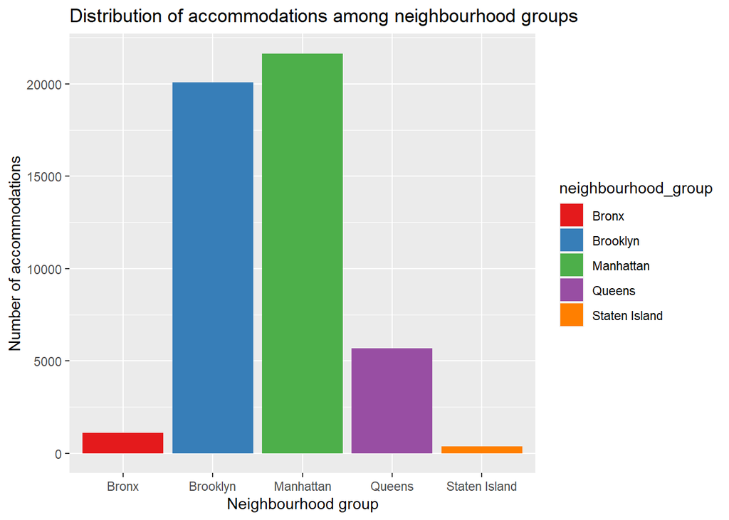

```r
ggplot(NYC_data, aes(x = neighbourhood_group, fill = neighbourhood_group)) +
  geom_bar() +
  scale_fill_brewer(palette = "Set1") +
  labs(title = "Distribution of accommodations among neighbourhood groups", x = "Neighbourhood group", y= "Number of accommodations")
```

Brooklyn and Manhattan have the most accommodations.

##### Let’s visualize the price of the accommodations for each neighbourhood group

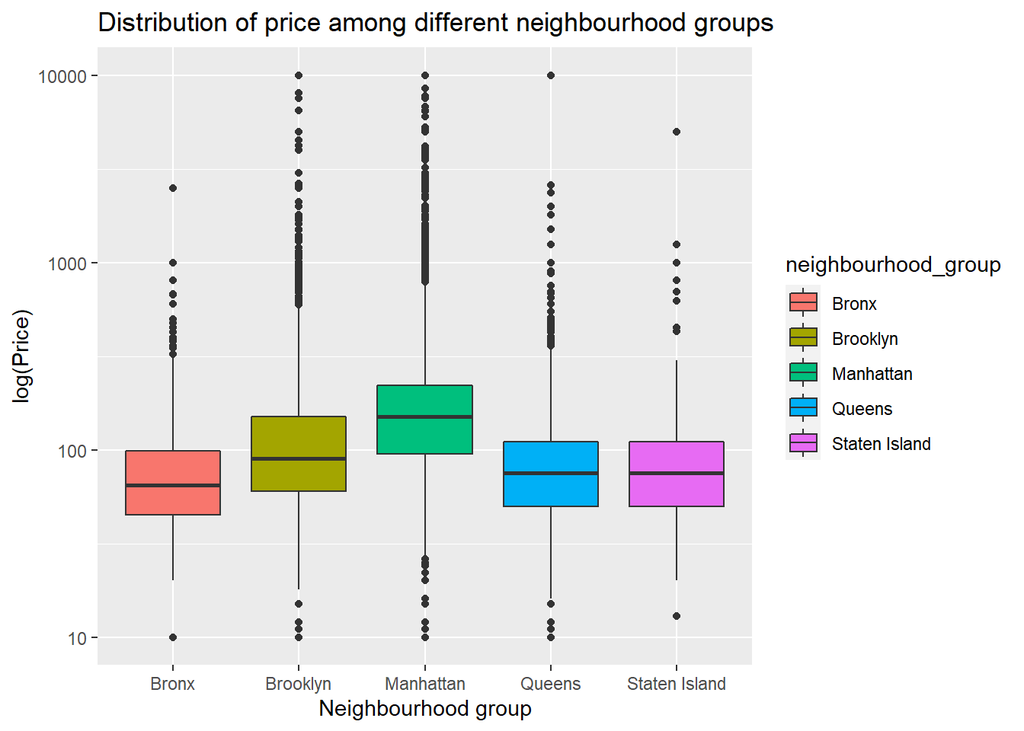

```r
ggplot(NYC_data, aes(y = price, x = neighbourhood_group, fill = neighbourhood_group)) +
  geom_boxplot() +
  scale_y_log10() + # We use the log of the price, because the range is too large. Otherwise, the boxplot is hard to read
  labs(title = "Distribution of price among different neighbourhood groups", x = "Neighbourhood group", y= "log(Price)")
```

We see that the prices are quite different for each neighborhood group. Manhattan seems to be the most expensive.

##### We can visualize the distribution of the prices on a map, by using the longitude and latitude data

##### Display the neighbourhood groups

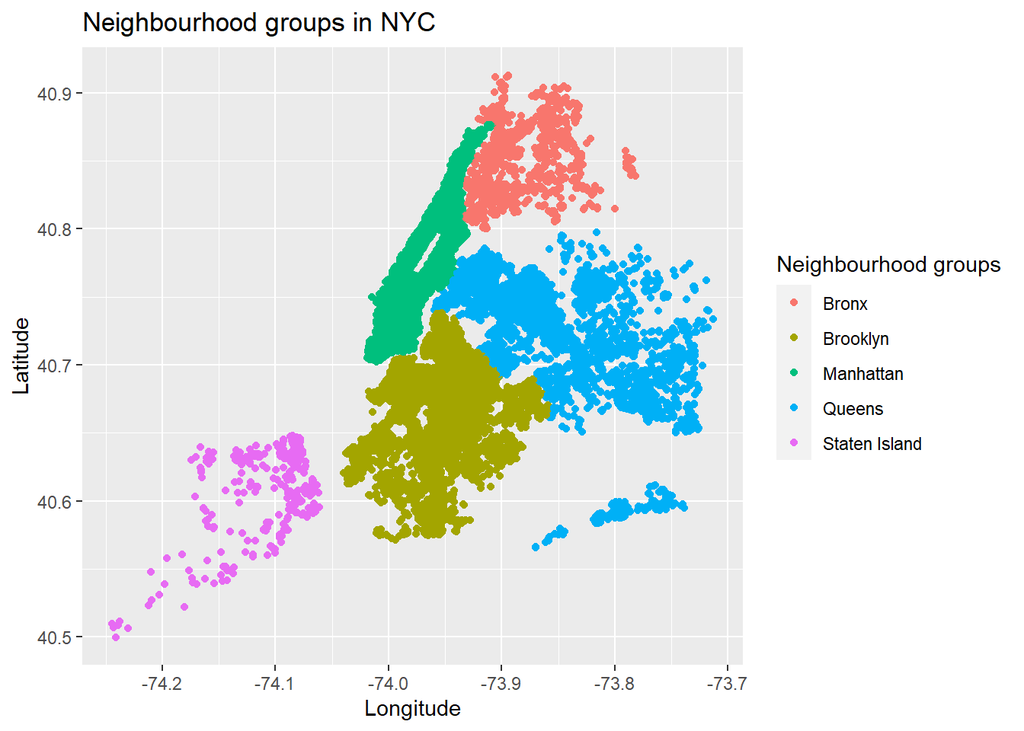

```r
NYC_data %>%
ggplot(aes(y = latitude, x = longitude, color = neighbourhood_group)) +
  geom_point() +
  labs(title = "Neighbourhood groups in NYC", x = "Longitude", y= "Latitude", color="Neighbourhood groups")
```

##### Display the prices of the accommodations

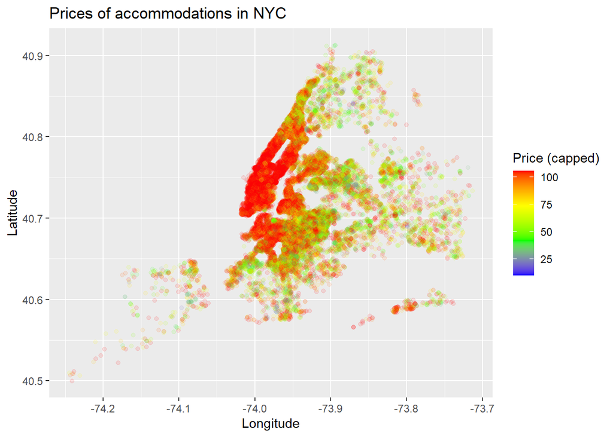

```r
#For better readability: we set the price above median price to median price
NYC_data %>%
  mutate(price_capped = ifelse(price > median(price),median(price),price)) %>% #Mute the data so that all prices above mean are set to mean price
  ggplot(aes(x=longitude, y= latitude, color= price_capped )) +
  geom_point(alpha = 1/10) +  # Add transparency because of large data set
  scale_colour_gradientn(colors = c("blue", "green", "yellow","red"))+
  labs(title = "Prices of accommodations in NYC", x = "Longitude", y= "Latitude", color="Price (capped)")
```

This also shows that Manhattan has the most accommodations with a price above the median (red dots)

## Hypothesis testing (t-test)

##### The exploratory analysis suggests that Manhattan might be the most neighbourhood group with the highest prices. Let’s try to back this claim up with some statistics.

##### Mean, median and standard deviation of the price for each neighbourhood group

```r
NYC_data %>%
  group_by(neighbourhood_group) %>%
  summarize(
    meanPrice = mean(price),
    medianPrice = median(price),
    sd = sd(price)) %>%
  arrange(desc(meanPrice))
```

```
## # A tibble: 5 x 4
##   neighbourhood_group meanPrice medianPrice    sd
##   <chr>                   <dbl>       <dbl> <dbl>
## 1 Manhattan               197.          150  291.
## 2 Brooklyn                124.           90  187.
## 3 Staten Island           115.           75  278.
## 4 Queens                   99.5          75  167.
## 5 Bronx                    87.5          65  107.
```

Manhattan has the highest mean and median price, however, the standard deviation is very high. The numbers indicate that Manhattan might be the neighbourhood group with the highest price.  
We next test whether this happens at random or if there is a statistically significant difference in the prices.

##### Let’s analyze whether the prices for accomondatons in Manhattan are statistically higher than in the rest of New York City.

##### Create dataset

```r
#Create dataset for t-test: One with accommodations from Manhattan and one data set with the rest
manhattan <- NYC_data %>%
  filter(neighbourhood_group == "Manhattan")

notManhattan <- NYC_data %>%
  filter(neighbourhood_group != "Manhattan")
```

##### Preconditions for t-test

```r
## 1. We can assume that the data is normally distributed, because of the large data set.
## 2. Before we do the t-test, we need to check for homogeneity of variance, because this determines whether to use the t-test or the Welch-test.
## Create a dummy variable to indicate the group (accommodation in Manhattan / not in Manhattan)

leveneTest_data <- NYC_data %>%
  mutate(ManhattanYes = ifelse(neighbourhood_group == "Manhattan",1,0))

## Levene-Test for homogeneity of variance across groups
### H0 for Levene-Test: There is homogeneity of variance for both groups ("both groups have similar variance")
### H1 for Levene-Test: There is no homogeneity of variance for both groups ("both groups have different variance")

leveneTest(leveneTest_data$price, leveneTest_data$ManhattanYes)
```

```
## Levene's Test for Homogeneity of Variance (center = median)
##          Df F value    Pr(>F)
## group     1  438.21 < 2.2e-16 ***
##       48845
## ---
## Signif. codes:  0 '***' 0.001 '**' 0.01 '*' 0.05 '.' 0.1 ' ' 1
```

##### T-test

H0: The price of accommodations in Manhattan equal to the price of accommodations in the rest of New York City

H1: The price of accommodations in Manhattan greater than the price of accommodations in the rest of New York City

```r
t.test(manhattan$price, notManhattan$price, var.equal = FALSE, conf.level = 0.95, alternative = "greater")
```

```
##
##  Welch Two Sample t-test
##
## data:  manhattan$price and notManhattan$price
## t = 34.921, df = 34553, p-value < 2.2e-16
## alternative hypothesis: true difference in means is greater than 0
## 95 percent confidence interval:
##  75.50704      Inf
## sample estimates:
## mean of x mean of y
##  196.9066  117.6671
```

We reject the Null Hypotheses (H0) and accept the alternative hypotheses (H1)  
Interpretation:  
This analysis shows that accommodations in Manhattan are statistically significantly more expensive (mean: 196.9066) compared to accommodations in the rest of New York City (117.6671).  
t(34553)=34.921, p < 2.2e-16.

## Hypothesis testing (ANOVA)

##### Let’s further analyze whether there are differences when also considering the room type of the accommodation.

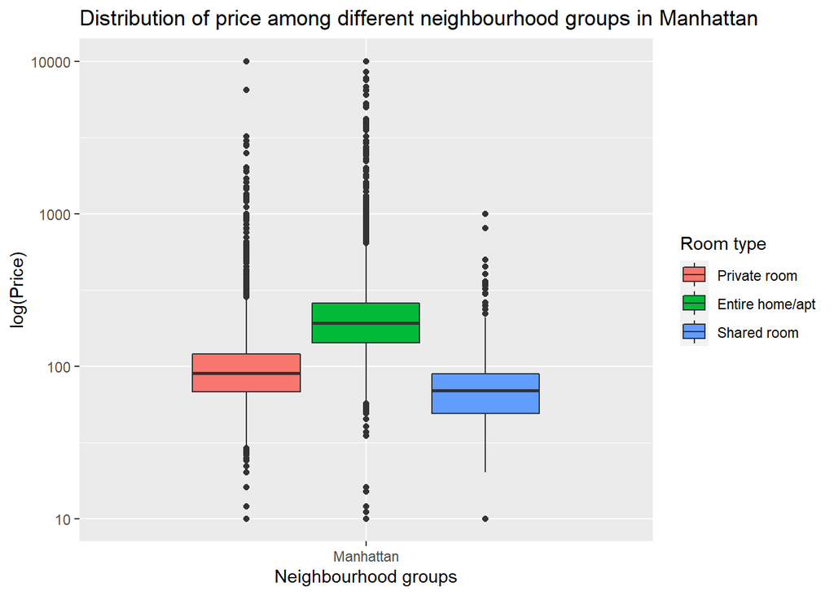

```r
manhattan_NYC_data <- NYC_data%>%
  filter(neighbourhood_group == "Manhattan")

manhattan_NYC_data %>%
  ggplot(aes(y = price, x = neighbourhood_group, fill = room_type)) +
  geom_boxplot() +
  scale_y_log10() +
  labs(title = "Distribution of price among different neighbourhood groups in Manhattan", x = "Neighbourhood groups", y= "log(Price)", fill="Room type")
```

```r
manhattan_NYC_data %>%
  group_by(room_type) %>%
  summarize(
    meanPrice = mean(price),
    medianPrice = median(price),
    sd = sd(price)) %>%
  arrange(desc(meanPrice))
```

```
## # A tibble: 3 x 4
##   room_type       meanPrice medianPrice    sd
##   <fct>               <dbl>       <dbl> <dbl>
## 1 Entire home/apt     249.          191 332.
## 2 Private room        117.           90 190.
## 3 Shared room          89.0          69  92.4
```

It seems like the type “entire home/apt” is the most expensive room type. But it is unclear whether the differences are actually significant.  
Let’s try to determine whether there are any statistically significant differences between the prices of the three room-types. We use a one-way ANOVA for this.

##### Preconditions for ANOVA

```r
## 1. We can assume normality of the data, because of the large dataset.
## 2. Before we do the ANOVA, we need to check for homogeneity of variance, because it determines whether to use the ANOVA or Welch's F-Test.

## Levene-Test for homogeneity of variance across groups
### H0 for Levene-Test: There is homogeneity of variance for all three groups
### H1 for Levene-Test: There is no homogeneity of variance for both groups

leveneTest(manhattan_NYC_data$price~manhattan_NYC_data$room_type)
```

```
## Levene's Test for Homogeneity of Variance (center = median)
##          Df F value    Pr(>F)
## group     2   125.8 < 2.2e-16 ***
##       21639
## ---
## Signif. codes:  0 '***' 0.001 '**' 0.01 '*' 0.05 '.' 0.1 ' ' 1
```

We reject H0 because the the Levene-Test shows that there is no variance homogeneity: F(2,21639) = 125.8, p = 2.2e-16. Therefore, we use the Welch’s F-Test.

##### Welch F-Test

H0: The mean price is equal for all three room types.  
H1: There is a significant difference in the mean price for all three room types.

```r
welch.test(price ~ room_type, data = manhattan_NYC_data)
```

```
##
##   Welch's Heteroscedastic F Test (alpha = 0.05)
## -------------------------------------------------------------
##   data : price and room_type
##
##   statistic  : 813.5969
##   num df     : 2
##   denom df   : 1667.792
##   p.value    : 2.55391e-247
##
##   Result     : Difference is statistically significant.
## -------------------------------------------------------------
```

There was a statistically significant difference between groups as determined by the Welch-F-Test (F(2,1667.792) = 813.5969, p < 0.05).  
We reject H0 and accept H1.  
Interpretation:  
We can see that the significance value is below 0.05 and, therefore, there is a statistically significant difference in the mean price per night between the different room types.  
This is great to know, but we do not know which of the specific room types differed. We can find this out with a Bonferroni post hoc test.

##### ANOVA Bonferroni Post Hoc test

```r
pairwise.t.test(manhattan_NYC_data$price, manhattan_NYC_data$room_type, p.adjust.method = "bonferroni")
```

```
##
##  Pairwise comparisons using t tests with pooled SD
##
## data:  manhattan_NYC_data$price and manhattan_NYC_data$room_type
##
##                 Private room Entire home/apt
## Entire home/apt <2e-16       -
## Shared room     0.11         <2e-16
##
## P value adjustment method: bonferroni
```

The Bonferroni post hoc test reveals that the price for “entire home/apt” is statistically significantly higher than for private (p = <0.05) and shared room (p = <0.05).  
There is no statistically significant difference between the shared and private (p = 0.11).

##### Conclusion:

Manhattan has significantly higher prices than the rest of NYC. Renting an entire home/apartment in Manhattan is significantly more expensive than renting a private room or shared room. However, there is no significant difference in the price for the shared or private room.